# Lecture 4: Benchmark Spread, Term Structure of Interest Rate, and Curve Strategies

Base rates, spot curves, forwards, and curve strategies

## Base interest rate

$$\text{Required yield}=\text{base interest rate}+\text{benchmark spread}$$

**Base rate**Minimal-default-risk return at the relevant horizon*→***Benchmark spread**Issuer and security-specific risks and features

Common bases: Treasuries, Treasury spots, swaps, and OIS for collateralized derivatives.

## Benchmark spread

The benchmark spread is the bond yield minus the yield of the benchmark security or curve.

**Five-year example:** corporate yield 5.05%, Treasury yield 3.80%.

$$5.05\%-3.80\%=1.25\%=125\text{ bp}$$

A second bond yields 6.20% against a 4.70% Treasury benchmark:

$$6.20\%-4.70\%=1.50\%=150\text{ bp}$$

Spreads change with credit conditions, liquidity, risk appetite, and the bond’s features. Match the benchmark to the cash-flow exposure.

## Issuer type shapes the spread

Sovereigns, agencies, supranationals, municipalities, financials, industrials, utilities, structured finance, and MBS issuers have different risks and protections.

| Issuer type | Yield | Spread over Treasury |
| --- | --- | --- |
| Federal agency | 4.35% | 35 bps |
| Utility company | 4.95% | 95 bps |
| High-yield industrial company | 7.25% | 325 bps |

Illustration: 10-year Treasury yield 4.00%.

## Creditworthiness

| Credit driver | Examples |
| --- | --- |
| Leverage and coverage | High debt/EBITDA versus low; weak versus strong coverage |
| Earnings and business risk | Cyclical commodity earnings versus stable utilities |
| Assets and recovery | Liquid collateral versus specialized assets |
| Diversification and industry | One product versus many; staples versus autos/airlines |
| Legal protection | Secured versus subordinated debt |

A-rated 7-year bond: **85 bp**; similar BBB bond: **145 bp**. The **60 bp** gap reflects weaker credit. Spreads can react before ratings.

## Embedded options shift value

### Issuer call

Limits investor upside when rates fall and creates reinvestment risk. Usually increases required spread.

### Investor put or conversion

Adds investor value. Can reduce required spread, sometimes below a comparable benchmark yield.

An AAA callable can trade wider than an AA putable or convertible if option value outweighs the credit difference.

## Raw spread mixes option and non-option effects

$$\text{Benchmark spread}=\text{OAS}+\text{embedded-option effects}$$

This is a conceptual decomposition, with option effects expressed in spread terms.

OAS requires a valuation model to remove the estimated effect of embedded options. Comparing raw yields alone can mis-rank bonds with different options.

## Tax treatment changes the comparison

$$y_{\text{after tax}}=y_{\text{taxable}}(1-t)$$

$$y_{\text{taxable equivalent}}=\frac{y_{\text{tax exempt}}}{1-t}$$

$$\frac{3.00\%}{1-0.35}=4.62\%$$

For an investor taxed at 35%, a 3% tax-exempt municipal yield is equivalent to a 4.62% taxable yield.

## Liquidity has a spread cost

Issue size, dealer inventory, trading frequency, price transparency, index eligibility, seasoning, and investor concentration affect saleability.

| Comparable BBB issue | Trading | Spread |
| --- | --- | --- |
| A: $2 billion | Daily benchmark trading | 140 bp |
| B: $150 million | Rarely trades | 175 bp |

The **35 bp** difference may largely reflect liquidity. Liquidity premiums can grow sharply in stressed markets.

## Financeability connects the bond and repo markets

**Manager owns bond**Pledges the security as collateral*→***Dealer lends cash**Repo rate is the financing cost*→***Leverage**Borrowing supports a larger position

Repo terms depend on tenor, collateral quality and liquidity, haircut, dealer demand, and scarcity of the specific issue.

## Special collateral can justify a lower cash yield

**Dealer needs a scarce bond**Often to cover a short position*→***Holder gets a lower repo rate**A financing advantage*→***Investors bid up its price**The bond’s cash yield falls

On-the-run Treasury richness can reflect both liquidity and special financing value.

## Financeability example: compare the whole position

| Issue | Cash yield | Repo rate | Financing status |
| --- | --- | --- | --- |
| On-the-run 5-year Treasury | 4.18% | 3.70% | Special collateral |
| Off-the-run 5-year Treasury | 4.28% | 4.10% | General collateral |

$$4.28\%-4.18\%=10\text{ bp lower cash yield on the on-the-run issue}$$

A leveraged investor also pays a financing rate. The larger cash yield alone does not identify the better carry.

## Financing carry reverses the ranking

$$\text{Financing carry}=\text{bond yield}-\text{repo rate}$$

$$\text{On-the-run}:4.18\%-3.70\%=0.48\%$$

$$\text{Off-the-run}:4.28\%-4.10\%=0.18\%$$

$$0.48\%-0.18\%=30\text{ bp carry advantage}$$

## Maturity creates a term structure

| Maturity sector | Term to maturity |
| --- | --- |
| Short term | 1 to 5 years |
| Intermediate term | 5 to 12 years |
| Long term | More than 12 years |

$$\text{Maturity spread}=y_{\text{long}}-y_{\text{short}}$$

Longer cash-flow horizons generally increase price volatility. Comparable securities across maturities define the term structure.

## Maturity spreads across sectors

[figure not shown]

Maturity spread: $4.75\%-3.80\%=0.95\%$.

## Term structure of interest rates

The term structure describes how rates vary with maturity. Each curve answers a different question.

| Curve | What it reports |
| --- | --- |
| Par | Coupon that prices a new bond at par |
| Spot | Discount rate for a single payment date |
| Forward | Implied rate between future dates |
| Swap | Par fixed swap rates under the relevant projection and discount curves |
| Credit spread | Additional compensation across risky maturities |

## YTM compresses a package into one rate

$$P=\sum_{t=1}^{n}\frac{CF_t}{(1+y)^t}$$

- YTM is the internal rate of return for promised cash flows, usually solved numerically.
- A coupon-bond YTM summarizes many payment dates in one rate.
- Realizing that compounded return requires holding to maturity, receiving all payments on time, and reinvesting coupons at YTM.

## Common yield-curve shapes

[figure not shown]

## Curve shapes provide clues, not mechanical rules

| Shape | Typical economy | Signal |
| --- | --- | --- |
| Upward sloping | Expansion or recovery | Growth and inflation expectations are rising. |
| Flat | Transition period | The outlook is uncertain. |
| Inverted | Late cycle or recession risk | Policy is tight and rate cuts may be expected. |
| Humped | Uneven outlook | Near-term pressure is high, but longer-term expectations are lower. |

Central-bank purchases, liquidity, Treasury supply, and maturity-specific demand can also change the curve.

## Individual cash flows require individual discount factors

$$P=\sum_{j=1}^{n}CF_jD(t_j)$$

- A spot rate prices one payment at one maturity.
- A five-year semiannual coupon bond has ten payment dates.
- Its own YTM reproduces its own price, but cannot supply a discount curve for other payment packages.

## Why one discount rate can misprice the package

Two-year annual bond: $50 coupon, $1,000 principal; $z_1=3\%$, $z_2=5\%$.

$$P_{\text{spot}}=\frac{50}{1.03}+\frac{1050}{1.05^2}=1000.92$$

$$P_{\text{one rate}}=\frac{50}{1.05}+\frac{1050}{1.05^2}=1000.00$$

## Constructing the theoretical Treasury spot curve

- **Goal:** find the value today of $1 paid at each selected future payment date, then express those discount factors as spot rates.
- **Securities:** use Treasury bills for the short end and Treasury coupon securities across the maturities we want to cover.
- **Inputs:** use full prices (clean prices plus accrued interest), coupon amounts, principal, and exact payment dates.
- **Consistency:** use a common observation and settlement date, with consistent day-count and compounding conventions.
- **Check:** the curve should reproduce the input securities’ full prices. Missing payment dates require interpolation or additional securities.

## Discount factors and spot rates

$D(t)$ is today’s value of $1 paid at maturity $t$, measured in years.

$$D(t)=(1+z(t)/2)^{-2t}$$

$$z(t)=2\left[D(t)^{-1/(2t)}-1\right]$$

The two curves contain the same information. Here $z(t)$ is a decimal annual rate with semiannual compounding.

## Bootstrapping from full prices

For the bond maturing at $t_n=n/2$, $C_n$ is its coupon in dollars per half year.

$$P_n=C_n\sum_{j=1}^{n-1}D(t_j)+(100+C_n)D(t_n)$$

$$D(t_n)=\frac{P_n-C_n\sum_{j=1}^{n-1}D(t_j)}{100+C_n}$$

Subtract the earlier coupons’ present value. The remaining price belongs to the final payment.

## Worked example: four prices, four discount factors

Illustrative Treasury-like securities, $100 face value, coupon-date settlement.

| Maturity | Annual coupon | Full price | Semiannual coupon |
| --- | --- | --- | --- |
| 0.5 year | 0% | 98.20 | 0.00 |
| 1.0 year | 3% | 99.10 | 1.50 |
| 1.5 years | 4% | 100.30 | 2.00 |
| 2.0 years | 5% | 101.20 | 2.50 |

The six-month instrument pays $100 once. All other payments fall on the same half-year grid.

## The first two discount factors

**Six-month bill:** its full price equals the present value of its only payment.

$$98.20=100D(0.5)\quad\Rightarrow\quad D(0.5)=\frac{98.20}{100}=0.982000$$

**One-year bond:** discount its first coupon and final coupon plus principal separately.

$$99.10=1.50D(0.5)+101.50D(1)$$

$$D(1)=\frac{99.10-1.50(0.982000)}{101.50}=0.961842365$$

$$z(1)=2\left[D(1)^{-1/2}-1\right]=3.928556\%$$

## The next two discount factors

$$D(1.5)=\frac{100.30-2[D(0.5)+D(1)]}{102}=0.945218777$$

$$D(2)=\frac{101.20-2.50[D(0.5)+D(1)+D(1.5)]}{102.50}
=0.916852167$$

Each successive security adds one unknown. A missing payment-date factor requires more information or an interpolation assumption.

## The bootstrapped spot curve

| Maturity | Discount factor | Annual semiannual spot quote |
| --- | --- | --- |
| 0.5 year | 0.982000000 | 3.665988% |
| 1.0 year | 0.961842365 | 3.928556% |
| 1.5 years | 0.945218777 | 3.791414% |
| 2.0 years | 0.916852167 | 4.387893% |

The 1.5-year spot is below the one-year spot. A valid curve need not rise at every maturity.

## Valuing a different coupon

A two-year bond pays $3 every half year and repays $100 principal.

$$P=3[D(0.5)+D(1)+D(1.5)]+103D(2)=103.102957$$

For $2 million face value:

$$V=(2{,}000{,}000/100)P=\$2{,}062{,}059.13$$

The payment dates and assumed credit quality match the curve. This bond was not used in the bootstrap.

## The par coupon is a derived quantity

The annual decimal coupon rate that makes a hypothetical bond worth $100 is:

$$c_{\mathrm{par}}(t_n)=\frac{2[1-D(t_n)]}{\sum_{j=1}^{n}D(t_j)}$$

The example’s two-year par coupon is **4.369402%**.

A published par curve can alternatively supply bootstrap inputs: set each price to 100 and each coupon to $100c_{\mathrm{par}}/2$. A par curve is not a required intermediate step when starting from bond prices.

## An existing par curve as an input

Suppose the supplied six-month and one-year par coupons are 3.60% and 3.80%, quoted annually with semiannual payments. Each hypothetical bond costs 100.

$$D(0.5)=\frac{100}{101.80}=0.982318271$$

$$D(1)=\frac{100-1.90D(0.5)}{101.90}\approx0.963038227$$

This converts a supplied par curve into discount factors. When starting from security prices, the direct price bootstrap already supplies those factors.

## Spot rates and derived par coupons

[figure not shown]

Both curves come from the same four illustrative prices.

## Missing dates require a modeling choice

Log-linear discount-factor interpolation between known dates $a$ and $b$:

$$\log D(t)=\frac{b-t}{b-a}\log D(a)+\frac{t-a}{b-a}\log D(b)$$

- Keeps discount factors positive
- Implies constant continuously compounded forwards within each interval
- Can affect prices between the observed dates

## On-the-run Treasuries: clear prices, sparse maturities

### Advantages

Recent issues are liquid, actively quoted, and useful for trader communication.

### Limitations

Few maturities; liquidity and special financing can make issues rich.

A 10-year on-the-run yield of 4.20% versus 4.25% on an older 9.8-year note may reflect a 5 bp liquidity difference rather than the pure discount curve.

## Treasury auction pattern in the notes

| Security | Maturities | Typical auction frequency |
| --- | --- | --- |
| Bills | 4-, 6-, 8-, 13-, 17-, and 26-week | Weekly |
| Bills | 52-week | Every 4 weeks |
| Notes | 2-, 3-, 5-, and 7-year | Monthly |
| Notes | 10-year | Quarterly original issue, with reopenings in other months |
| Bonds | 20- and 30-year | Quarterly original issue, with reopenings in other months |
| TIPS | 5-, 10-, and 30-year | Less frequent; varies by maturity |
| FRNs | 2-year | Quarterly original issue, with reopenings in other months |

Typical pattern as stated in the lecture notes; actual auction schedules can change.

## Adding selected off-the-run issues

### More observations

Better coverage between benchmark maturities and less reliance on a few rich issues.

### Selection risk

Stale quotes, lower liquidity, special financing, coupon and tax effects can distort the fit.

## Using all Treasury bills and coupon securities

### Broad coverage

Many observations support a smooth curve and reduce dependence on benchmark issues.

### Cleaning the inputs

Liquidity, supply and demand, taxes, financing, and coupon effects still matter.

Statistical fitting controls issue-specific noise and outliers.

## A coupon bond is a package of zeros

| Date | Coupon payment | Principal payment | Total cash flow | Equivalent zero-coupon bond |
| --- | --- | --- | --- | --- |
| Year 1 | $5 | $0 | $5 | 1-year zero paying $5 |
| Year 2 | $5 | $0 | $5 | 2-year zero paying $5 |
| Year 3 | $5 | $100 | $105 | 3-year zero paying $105 |

$$P=\frac5{1+z_1}+\frac5{(1+z_2)^2}+\frac{105}{(1+z_3)^3}$$

This illustrative annual-pay bond uses annual effective spot rates. Treasury notes in the market generally pay semiannually.

## STRIPS reveal one-date discount rates

### Advantages

Single-payment yields directly reveal spot rates, remove coupon effects, and support long-maturity estimates.

### Limitations

Lower liquidity, pension demand, and incomplete maturity coverage can affect prices.

$$z_{10}=\left(\frac{100}{62}\right)^{1/10}-1=4.90\%$$

A $100 payment in ten years trades for $62. The formula reports an annual effective rate.

## Using the theoretical spot rate curve

For annual-pay cash flows and annual effective spot rates:

$$P=\sum_{t=1}^{n}\frac{CF_t}{(1+z_t)^t}$$

- Match each discount rate to its payment date.
- Include principal in the final cash flow.
- Use consistent credit quality and compounding conventions.

## Spot valuation: a three-year Treasury

Illustrative annual-pay bond, 4% coupon, $100 face value. Annual effective spots:

| Maturity | Spot rate |
| --- | --- |
| 1 year | 3.50% |
| 2 years | 4.00% |
| 3 years | 4.40% |

$$P=\frac4{1.035}+\frac4{1.04^2}+\frac{104}{1.044^3}=98.96$$

## Spot rates and the base interest rate

$$P=\sum_{t=1}^{n}\frac{CF_t}{(1+z_t+s)^t}$$

$z_t$ is the Treasury spot for payment date $t$; $s$ is a constant spread over that curve.

This respects cash-flow timing more closely than subtracting one Treasury YTM from the bond’s YTM.

## Spot rates as base rates: adding a credit spread

Corporate promised payments: $5 in year 1 and $105 in year 2. Treasury spots: 3.00% and 3.50%.

$$P_{\text{base}}=\frac5{1.03}+\frac{105}{1.035^2}=102.87$$

This is the value of those payments discounted at Treasury base rates.

Add a constant **120 bp spread** to the same payment-date rates:

$$3.00\%+1.20\%=4.20\%,\qquad3.50\%+1.20\%=4.70\%$$

$$P_{\text{risky}}=\frac5{1.042}+\frac{105}{1.047^2}=100.58$$

## Forward rates connect two investment routes

**Two-year route:** invest now at the two-year spot.

**Rollover route:** invest one year, then reinvest at the forward rate locked today.

**No arbitrage**  
Both routes must end with the same value.

$$(1+z_2)^2=(1+z_1)(1+f_{1,2})$$

## Deriving a one-year forward rate

$$f_{1,2}=\frac{(1+z_2)^2}{1+z_1}-1$$

$$z_1=4.00\%,\quad z_2=4.80\%$$

$$f_{1,2}=\frac{1.048^2}{1.04}-1=5.61\%$$

The rate covers year 1 to year 2. It is implied today, not a new observed future spot rate.

## A forward rate above fair value creates an arbitrage

Now use $z_1=4\%$ and $z_2=5\%$. The fair forward is 6.01%. Suppose the market forward is **7%**.

**Borrow two years**At 5%*→***Invest one year**At 4%*→***Lock year-two reinvestment**At 7%

$$\text{Owed}=100(1.05)^2=110.25$$

$$\text{Investment}=100(1.04)(1.07)=111.28$$

$$\text{Profit}=111.28-110.25=1.03$$

If the forward is too low, reverse the trade: invest two years and finance with one-year borrowing plus locked forward borrowing.

The example assumes the same frictionless borrowing and lending rates.

## Six-month spots are geometric averages

$$(1+z_t)^t=(1+z_1)(1+f_1)\cdots(1+f_{t-1})$$

$$z_t=\left[(1+z_1)\prod_{i=1}^{t-1}(1+f_i)\right]^{1/t}-1$$

In this section, $t$ counts half-year periods and both $z_t$ and $f_i$ are **six-month periodic rates**. They are not the annualized spot quotes used in the bootstrap.

## Adjacent spots imply six-month forwards

$$f_i=\frac{(1+z_{i+1})^{i+1}}{(1+z_i)^i}-1$$

Compare investing directly for $i+1$ periods with investing for $i$ periods and reinvesting for one more period. The forward rate makes the ending values equal.

## Spot-to-forward example: periods 1–5

| Period | Maturity | Spot rate per six months | Bond-equivalent spot rate |
| --- | --- | --- | --- |
| 1 | 0.5 year | 2.625% | 5.250% |
| 2 | 1.0 year | 2.750% | 5.500% |
| 3 | 1.5 years | 2.880% | 5.760% |
| 4 | 2.0 years | 3.077% | 6.154% |
| 5 | 2.5 years | 3.250% | 6.500% |

Bond-equivalent annual rate is twice the displayed periodic rate.

## Spot-to-forward example: periods 6–10

| Period | Maturity | Spot rate per six months | Bond-equivalent spot rate |
| --- | --- | --- | --- |
| 6 | 3.0 years | 3.427% | 6.854% |
| 7 | 3.5 years | 3.453% | 6.906% |
| 8 | 4.0 years | 3.578% | 7.156% |
| 9 | 4.5 years | 3.635% | 7.270% |
| 10 | 5.0 years | 3.660% | 7.320% |

Bond-equivalent annual rate is twice the displayed periodic rate.

## The first two implied forward rates

$$f_1=\frac{1.02750^2}{1.02625}-1=2.875\%$$

$$f_2=\frac{1.02880^3}{1.02750^2}-1=3.140\%$$

$f_1$ covers 0.5–1.0 year. $f_2$ covers 1.0–1.5 years. These are six-month rates.

## The full six-month forward curve

| Forward rate | Period covered | Six-month rate |
| --- | --- | --- |
| $f_1$ | 0.5 to 1.0 year | 2.875% |
| $f_2$ | 1.0 to 1.5 years | 3.140% |
| $f_3$ | 1.5 to 2.0 years | 3.670% |
| $f_4$ | 2.0 to 2.5 years | 3.945% |
| $f_5$ | 2.5 to 3.0 years | 4.317% |
| $f_6$ | 3.0 to 3.5 years | 3.609% |
| $f_7$ | 3.5 to 4.0 years | 4.457% |
| $f_8$ | 4.0 to 4.5 years | 4.092% |
| $f_9$ | 4.5 to 5.0 years | 3.885% |

Calculated from the displayed spot inputs, with forward rates rounded to three decimals.

## Reconstructing the five-year spot

Ten half-year growth factors consist of today’s six-month spot and nine forwards. Use unrounded forwards derived from the spot inputs.

$$G=(1+z_1)\prod_{i=1}^{9}(1+f_i)=(1.03660)^{10}$$

$$G=1.432557,\qquad z_{10}=G^{1/10}-1=3.660\%$$

Bond-equivalent quote: $2(3.660\%)=7.320\%$.

The calculation uses unrounded forwards derived from the displayed spot rates.

## Forward rates implied by the example

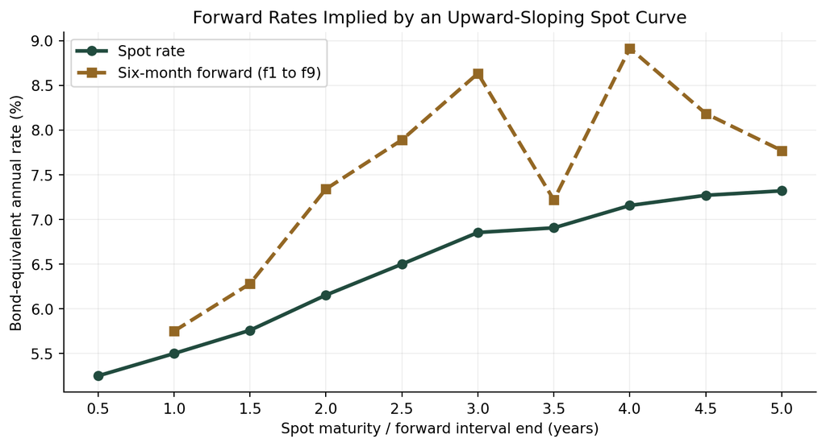

Both series use the preceding ten spot inputs. Forward points mark interval ends. The decline at year 3.5 corresponds to $f_6$.

## Forwards can cover any future interval

$$1+f_{a,b}=\left[\frac{(1+z_b)^b}{(1+z_a)^a}\right]^{1/(b-a)}$$

Annual compounding, with maturities in years. For $z_3=4.00\%$ and $z_5=4.60\%$:

$$f_{3,5}=\left(\frac{1.046^5}{1.040^3}\right)^{1/2}-1=5.51\%$$

This locks a two-year rate beginning three years from now.

## A forward rate is a hedgeable break-even rate

Forward rates can differ from realized future rates because of risk premiums, liquidity, and changing economic conditions.

### Lock the longer rate

Hedges reinvestment uncertainty today.

### Roll the shorter investment

Leaves the future reinvestment rate uncertain.

Compare your rate expectation with the forward break-even, not just with today’s short rate.

## One-year horizon: lock or roll?

Six-month spot: 5.00% bond-equivalent, or 2.50% periodic.

One-year spot: 5.37% bond-equivalent, or 2.685% periodic.

$$f_1=\frac{1.02685^2}{1.0250}-1\approx2.870334\%$$

The forward break-even is **5.740668% bond-equivalent**.

Below that expected future rate: prefer the locked one-year investment. Above it: rolling six months is expected to earn more.

## Term-structure shape reflects several forces

**Expectations**Policy, inflation, growth*→***Risk compensation**Duration and liquidity premiums*→***Supply and demand**Maturity preferences, safe havens, balance-sheet constraints

No single theory explains the curve at every date.

## Pure expectations theory

- Forward rates reflect expected future short rates alone.
- Investors require no maturity risk premium.
- An upward slope signals expected rate increases under this theory.
- An inverted curve signals expected cuts.
- **Limitation:** duration risk and risk premiums complicate this interpretation.

## Liquidity theory

- Investors prefer short maturities because of lower price risk and greater liquidity.
- Longer maturities require a positive premium.
- An upward curve can persist even when expected short rates are unchanged.

$$y_{\mathrm{long}}\approx\text{expected average short rates}+\text{liquidity premium}$$

## Preferred habitat theory

- Investors and borrowers prefer particular maturity ranges.
- Money funds favor short maturities.
- Banks may favor intermediate maturities.
- Insurers and pensions often seek long maturities to match liabilities.
- Sufficient compensation can induce investors to leave their preferred range.

Strong long-maturity demand can lower long yields relative to expectations alone.

## Market segmentation theory

- Supply and demand determine yields within relatively separate maturity sectors.
- The 2-year sector may reflect policy expectations.
- The 30-year sector may reflect pension demand, inflation uncertainty, and long-duration supply.
- **Limitation:** arbitrage and relative-value trading connect the sectors.

## Main influences on the yield curve

| Influence | Main intuition |
| --- | --- |
| Expected future rate changes | Longer investments compete with rolling short investments |
| Bond risk premiums | Investors demand compensation for duration and other risks |
| Convexity bias | Nonlinear price sensitivity affects value and required yields |

The observed curve combines these effects.

## Expectations can reshape the curve

[figure not shown]

Expected tightening can raise 1–5Y yields and flatten or invert the curve. Expected easing can lower intermediate yields; recession expectations can pull longer yields down.

## Bond risk premiums move independently of expectations

| Force | Possible curve effect |
| --- | --- |
| Inflation uncertainty | Higher long-term premium; steepening |
| Heavy long-term issuance | Long maturities cheapen; yields rise |
| Pension and insurer demand | Lower long-end premium; flattening |
| Safe-haven buying | Lower Treasury yields at liquid benchmarks |

Expected short rates can be unchanged while risk premiums move.

## Convexity also has value in the curve

### Positive convexity

Investors may accept lower yields for favorable price asymmetry, especially when rates are volatile.

### Negative convexity

Callables and MBS sacrifice upside when rates fall and require compensation for exercise or prepayment risk.

The observed curve combines expectations, risk premiums, and convexity effects.

## Swap rate yield curve

**Party A**Pays fixed 4.50%*→***$100m notional**Principal is not exchanged*→***Party B**Pays floating compounded SOFR

$$\text{Semiannual fixed payment}=\$100m\times4.50\%/2=\$2.25m$$

Five-year fixed-for-floating swap. A receives floating; B receives fixed.

## Swap payments depend on realized overnight rates

| Scenario for annualized compounded SOFR over six months | Floating payment | Net cash flow |
| --- | --- | --- |
| SOFR = 3.50% | $1,750,000 | Party A pays Party B $500,000 |
| SOFR = 4.50% | $2,250,000 | No net payment |
| SOFR = 5.50% | $2,750,000 | Party B pays Party A $500,000 |

Higher realized SOFR raises A’s floating receipt. These illustrative payments assume an accrual fraction of 0.5.

## Swap rates form a benchmark curve

The par swap rate makes the initial swap value approximately zero. Active trading across maturities makes the curve useful for corporate and structured-product valuation and hedging.

$$\text{Swap spread}=\text{swap rate}-\text{Treasury yield}$$

$$4.65\%-4.25\%=0.40\%=40\text{ bp}$$

Swap spreads reflect collateralized derivatives, bank balance sheets, reference rates, and relative market conditions.

## Treasury and swap curves

[figure not shown]

The swap curve is not identical to the Treasury curve. Many users hedge with swaps, making swap rates a useful benchmark for their cash flows.

## Curve strategies: level, slope, and curvature

**Level**Broad rate move*→***Slope**Short versus long rates*→***Curvature**Belly versus wings

- Express views on level, slope, or curvature using **bonds, futures, or swaps**.
- Use **duration-adjusted positions** to reduce unintended parallel-shift exposure.

## Bull steepener: short rates fall more

Long 2-year notes and short 10-year notes in duration-adjusted amounts.

|  | 2Y | 10Y | 2s10s slope |
| --- | --- | --- | --- |
| Initial | 4.80% | 4.20% | −60 bp |
| After | 4.10% | 3.95% | −15 bp |
| Move | −70 bp | −25 bp | +45 bp |

- **Position:** long 2Y and short 10Y with equal initial dollar DV01.
- **Profit:** the slope increases. Here it increases by 45 bp.
- **Loss:** the slope decreases, before carry and other effects.
- First-order price P&L is common DV01 times the slope change in bp.

## Bull steepener: the curve move

[figure not shown]

## Bear steepener: long rates rise more

Short 30-year bonds and long 5-year notes in duration-adjusted amounts.

|  | 5Y | 30Y | 5s30s slope |
| --- | --- | --- | --- |
| Initial | 4.00% | 4.40% | 40 bp |
| After | 4.10% | 4.80% | 70 bp |
| Move | +10 bp | +40 bp | +30 bp |

- **Position:** long 5Y and short 30Y with matched dollar DV01.
- **Profit:** long yields rise more, widening the slope by 30 bp here.
- **Loss:** the slope narrows. Financing and curve-basis changes can also hurt.

## Bear steepener: the curve move

[figure not shown]

## Bull flattener: long rates fall more

Long 10-year notes; short 2-year notes in duration-adjusted amounts.

- **Example:** 10Y falls 50 bp while 2Y falls 15 bp, narrowing the slope by 35 bp.
- **Profit:** the long-end gain exceeds the short-end loss when dollar DV01s match.
- **Loss:** the slope steepens, before carry and other effects.
- Declining inflation expectations or demand for duration can motivate the trade.

## Bull flattener: the curve move

[figure not shown]

## Bear flattener: short rates rise more

Short 2-year notes; long 10-year notes in duration-adjusted amounts.

- **Example:** 2Y rises 75 bp while 10Y rises 25 bp, narrowing the slope by 50 bp.
- **Profit:** the short-end gain exceeds the long-end loss when dollar DV01s match.
- **Loss:** the slope steepens, before carry and other effects.
- Expected monetary tightening can motivate the trade.

## Bear flattener: the curve move

[figure not shown]

## Butterfly: the belly versus the wings

$$\text{Butterfly}=2y_5-y_2-y_{10}$$

$$2(4.50\%)-4.00\%-4.30\%=0.70\%$$

The 5-year point is high relative to the 2-year and 10-year wings. A trader expecting it to richen buys 5Y and shorts the wings in duration-adjusted amounts.

## Butterfly: position and outcome

- **Position:** long 5Y, short 2Y and 10Y.
- To track $2y_5-y_2-y_{10}$, allocate dollar DV01 in the ratio $-1:+2:-1$.
- **Profit:** the belly yield falls relative to the wings, reducing the butterfly.
- **Loss:** the belly cheapens relative to the wings.
- In the plotted scenario, yields become 4.05%, 4.15%, and 4.25%.

$$2(4.15\%)-4.05\%-4.25\%=0.00\%$$

The butterfly falls from 70 bp to zero. Neutrality to a parallel move does not remove every slope or curvature exposure.

## Butterfly: relative richening of the belly

[figure not shown]

## Carry and roll-down are separate return sources

### Carry

Coupon income less financing cost from holding the position.

### Roll-down

Price effect as the bond ages to a shorter maturity on an unchanged curve.

- **Profit contribution:** coupon income, less financing, plus potential price gain from a 30 bp roll-down.
- **Loss risk:** higher yields or financing costs can outweigh both benefits.

## Curve risk controls extend beyond total duration

| Exposure or cost | Control |
| --- | --- |
| Level and maturity location | Duration and key rate duration |
| Large moves | Convexity and scenario repricing |
| Holding the position | Financing cost and liquidity |
| Adverse outcomes | Stop-loss levels and stress scenarios |

Duration neutrality applies only locally to parallel shifts. Volatility, financing changes, unexpected curve moves, and hedge basis risk can still create losses.

## Broad picture

### 1. Observe

Full Treasury prices, coupons, and payment dates at a common settlement date.

### YTM Is a Summary

A YTM is one IRR for a bundle of cash flows, not a one-date discount rate.

Observed Treasury yields are heterogeneous.

coupon

maturity

cash-flow

liquidity

tax

financing

→calibrate

### 2. Discount Factors

Bootstrap or fit payment-date discount factors. Specify interpolation and check input repricing.

→convert

### 3. Spot Rate Curve

Express each discount factor as a spot rate under a stated compounding convention.

↓use spots

↓derive

### 4. Price Cash Flows

Value comparable Treasury cash flows. Derive the coupon that prices a hypothetical bond at par.

### 5. Forward Rates

Forward rates describe future start dates and tenors implied by spot rates.

↓apply

### 6. Hedge or Trade

Use suitable bonds or derivatives to hedge exposure or express a rate view. Implied forwards are break-even rates.